# Notes on MySQL

This html file is made as part of the documentation for SISAL version 1b as of the 21st of January 2019.

## How to install **MySQL**

Install MySQL community server and MySQL Workbench. see: https://dev.mysql.com/downloads/mysql/

MySQL Workbench will help you visualise the database better.

## How to import SISAL database into MySQL through MySQL workbench

#### Step 1. Open MySQL Workbench and connect to MySQL server.

[figure not shown]

#### Step 2. Import database: Server>Data Import

[figure not shown]

#### Step 3. Import database:

1. Select "Import from Self-Contained file"  
2. Browse to find the SQL file you have downloaded from http://dx.doi.org/10.17864/1947.189  
3. Press New to import into a new 'schema'/database. Call this anything you want (i.e. sisalv2).  
4. Start import

[figure not shown]

#### Step 4. Run queries:

1. This is where you type your queries.  
2. This is how you run the queries. You can also press ctr+enter.  
3. You can save these queries in an SQL file which you can view later (SQL file is essentially a text file).

[figure not shown]

## Database structure

The structure of the database can be found below:

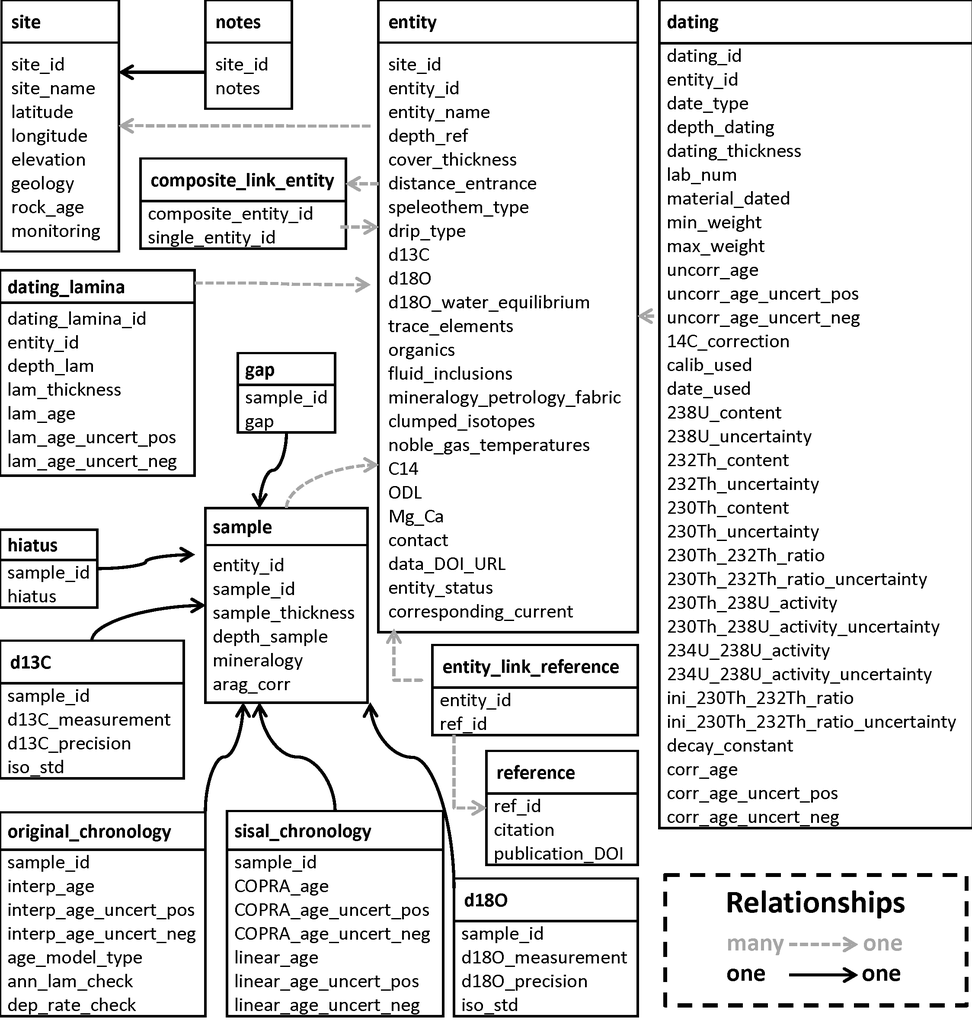

Please note that in different operating systems, table names may appear slightly differently. In UNIX systems, uppercases in table names is shown as uppercases, but not in Windows system (table d18O will be seen as d18o). However, this does not effect the queries at all as the queries are case insensitive.

## Example queries

These set of queries assume that the database has been downloaded and is in MySQL under the name: **sisalv2**

#### 0. Tells MySQL that we are using the 'sisalv2' database. By doing this at the start, you will be able to miss out the database name out of the queries.

```
USE sisalv2;
```

#### 1. Select everything from any given table.

```
SELECT * from sisalv2.site;
```

This query translates to 'select everything from 'sisalv2' database, 'site' table. Try this same query but replace 'site' with whichever table you want.

#### 2. Count how many entities are in the database.

```
SELECT count(*) from sisalv2.entity;
```

#### 3. Select two variables from one table (ie site name and coordinates).

```
SELECT site.site_name, site.latitude, site.longitude FROM sisalv2.site;
```

#### 4. Select two variables from two different tables (ie table with site name and the corresponding entity names).

```
SELECT entity.entity_name, site.site_name FROM entity, site WHERE entity.site_id = site.site_id;
SELECT entity.entity_name, site.site_name FROM site LEFT JOIN entity USING(site_id);
```

Note that there are different types of 'JOIN' statement. If not specified (only 'JOIN', the default 'INNER JOIN' is used). see:https://www.w3schools.com/sql/sql_join.asp

#### 5. Rename columns.

```
SELECT site_name as `site site name`, longitude, latitude, elevation as `masl` FROM site;
```

#### 6. Extract note linked to site name (instead of site_id).

```
SELECT site.site_name, notes.notes from site LEFT JOIN notes USING(site_id);
```

#### 7. Extract dating table as in the workbook for a specific entity_id.

```
SELECT dating.* FROM dating, entity WHERE entity.entity_id = dating.entity_id AND entity.entity_id =254;
```

#### 8a. Extract site.site_name, entity.entity_name only for composites and entity_name of entities forming the comp. Note that data on the individual records composing the Soreq_composite is not available. 'compe' is the name given to the entity table when linking entity to the composite_link_entity table (for composite entities) while 'single_ent' is the name given to the entity table when linking entity and composite_link_entity (for single entities). This is done because there are only the column names will be repeated and we will not be able to distinguish which entity name are the composites or the individual entities.

[output not shown]

#### 8b. Extract site.site_name, entity.entity_name only for composites and entity_name of entities forming the comp, but one row per composite entity. Note that data on the individual records composing the Soreq_composite is not available.

[output not shown]

#### 9. Create huge table with the following variables: site.site_name, site.latitude, site.longitude, entity.entity_name, sample.sample_id, d18O.d18O_measurement, hiatuses and original_chronology.interp_age with its uncertainties and remove from this table rows for which original_chronology.interp_age is NULL.

[output not shown]

#### 10. Extract d18O_measurements, hiatuses, interpolated ages and its uncertainties for all entities from "Liang Luar cave".

[output not shown]

#### 11. Extract d18O_measurements, hiatuses, interpolated ages and its uncertainties for all calcite samples which d18O water is in equilibrium and has interpolated ages.

[output not shown]

#### 12. Extract d18O_measurements, hiatuses, interpolated ages and its uncertainties for all aragonite samples which has been corrected for and has interpolated ages.

[output not shown]

#### 13. Extract d18O_measurements, hiatuses, interpolated ages and its uncertainties from "LR07-E1", from "Liang Luar cave". Note that we should always specify the site name as there could be entities with the same name from multiple sites.

[output not shown]

```
SELECT entity.* FROM entity WHERE entity_id in (SELECT entity_id FROM (SELECT * from dating  WHERE date_type NOT LIKE '%Event%' AND date_type != 'unknown') AS T GROUP BY entity_id HAVING count(distinct(T.date_type)) > 2);
```

#### 15. Extract details of entities and dating information which were used in author's age model reconsturction and the date type is of U/Th methods ('MC-ICP-MS U/Th', 'ICP-MS U/Th Other', 'Alpha U/Th', 'TIMS' and 'U/Th unspecified') and the speleothem type is not flowstone. Note that this query is relatively long as I queried for the hiatuses as well. If we only query this once, we will only get the dates but miss out the 'Events' which may be useful for age model reconstruction.

[output not shown]

```
SELECT entity.* FROM entity WHERE entity_id in (SELECT distinct(entity_id) FROM entity RIGHT JOIN dating_lamina USING(entity_id) LEFT JOIN sample USING(entity_id) LEFT JOIN original_chronology USING(sample_id) WHERE ann_lam_check != 'unknown');
```

#### 17. Extract list of all entities for which interpolated ages are not available (partially or totally, omitting samples that only provide information on hiatuses).

```
SELECT * FROM entity WHERE entity_id in (SELECT distinct(entity_id) FROM sample LEFT JOIN original_chronology USING(sample_id) LEFT JOIN hiatus USING(sample_id) WHERE interp_age IS NULL AND hiatus IS NULL);
```

#### 18. Extract site name, entity name, date type, depths, depth reference point, corrected age of dates used in the original age models for LR07-E1 from Liang Luar cave.

```
SELECT site.site_name, entity.entity_name, dating.date_type, dating.depth_dating, entity.depth_ref, dating.corr_age FROM site LEFT JOIN entity USING(site_id) LEFT JOIN dating USING(entity_id) WHERE dating.date_used = 'yes' AND entity_name = 'LR07-E1' AND site_name = 'Liang Luar cave';
```

#### 19. Extract site details and the average d18O measurements.

```
SELECT site.*, count(distinct(entity.entity_id)) as 'entity_counts', avg(d18O.d18O_Measurement) as 'mean_d18O' FROM site LEFT JOIN entity USING (site_id) LEFT JOIN sample USING (entity_id) LEFT JOIN d18O USING (sample_id) GROUP BY site.site_id;
```

#### 20. Extract d18O samples which ages are younger than 22000 years old and older than 1000 years old (BP 1950). This type of queries work with all columns which are numeric.

[output not shown]

### Additional queries

#### Selecting specific columns from the site table in the database.

```
SELECT site_name, latitude from sisalv2.site;
SELECT site.site_name, site.latitude from sisalv2.site;
```

These two queries translate to 'select site_name and latitude from 'sisalv2' database, 'site' table. The second query specifies exactly what type table the column is in. This is not necessary when all the column names are unique, but this can be a problem when you join tables which contains the same column names.

#### Selecting information from a joint site and entity table.

```
SELECT * from sisalv2.site JOIN sisalv2.entity USING(site_id);
SELECT site.site_name, entity.entity_name from sisalv2.site JOIN sisalv2.entity USING(site_id);
```

The first query simply translates to 'select everything from site table joined to entity table using the site_id'.  
The second query only selects the site name and the entity name.

#### Selecting entity information from a joint site and entity table where the site is at elevation above 500 metres and contain carbon isotope data.

```
SELECT entity.* from sisalv2.site LEFT JOIN sisalv2.entity USING(site_id) WHERE site.elevation >= 500 AND entity.d13C = 'yes';
```

```
SELECT distinct(contact) from sisalv2.entity WHERE entity.d13C = 'yes';
```

#### Selecting all dating information in the database where the dating methods are U/Th or TIMS.

```
SELECT * FROM dating WHERE (date_type LIKE '%U/Th%' OR date_type = 'TIMS');
```

#### Selecting all dating information in the database with lamination events.

```
SELECT * FROM dating WHERE (date_type LIKE '%Event%laminations');
```

## Additional details

There are several connectors to MySQL in different programming language. Some of these connectors may be installed during the installation process. Please check: https://dev.mysql.com/doc/refman/5.7/en/connectors-apis.html  
The table in the link above also list the 'APIs'/modules in different languages Python: check the "MySQLdb" module  
R: check the "RMySQL" module